# Analysis of the trend of Michigan Consumer Sentiment Index in the past and prediction in the future

## 7.Further Exploration

```r
midtermda2<-read.table("price_level.txt",header=T)
combine<-read.table("consumer-price.txt",header=T)
chgmod3<-lm(combine$Pricelevel~combine$VALUE,midtermda2)
summary(chgmod3)
```

```
##
## Call:
## lm(formula = combine$Pricelevel ~ combine$VALUE, data = midtermda2)
##
## Residuals:
##     Min      1Q  Median      3Q     Max
## -4.1606 -1.3182  0.4424  1.5348  2.0360
##
## Coefficients:
##               Estimate Std. Error t value Pr(>|t|)
## (Intercept)   93.70086    2.23066  42.006  < 2e-16 ***
## combine$VALUE  0.08082    0.02496   3.238  0.00301 **
## ---
## Signif. codes:  0 '***' 0.001 '**' 0.01 '*' 0.05 '.' 0.1 ' ' 1
##
## Residual standard error: 1.847 on 29 degrees of freedom
## Multiple R-squared:  0.2655, Adjusted R-squared:  0.2402
## F-statistic: 10.49 on 1 and 29 DF,  p-value: 0.00301
```

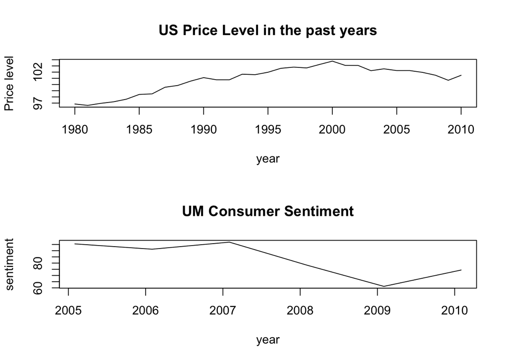

```r
par(mfcol=c(2,1))
plot(midtermda2$year,midtermda2$Pricelevel,xlab='year',ylab='Price level',type='l',main="US Price Level in the past years")
plot(tdx[c(26:390)],csent[c(26:390)],xlab='year',ylab='sentiment',type='l',main="UM Consumer Sentiment")
```

We retrived price-level index data from FED, and combine the two data sets of price level and UMCSI together, and form a new dataset:consumer-price. The linear Regression shows that the correlation between Price Level and MCSI is statistically significant, and they are positively correlated. Therefore, we could briefly have an idea that Higer consumer Sentiment stimulates consumption, and may lead to higher price level, $\textbf{even the model only provides a basic intuition that can not justify any causal correlation.}$ Noticed that $R^2$ is only 26.6%, which indicates just a small proportion of variation can be explained by the simple correlation effect.

Also, we find the two time series plots shows roughly similar pattern, especially both decrease in Year 2008 in this history. Therefore, in the futurn exploration, I will be interested in connecting two factors over the time history and try to dig out the true causality behind them.

## 8.Reference

1.Amadeo, K. (2020, Mar 1). What Will the Economy Do in 2019 and Beyond? Retrieved from https://www.thebalance.com/us-economic-outlook-3305669.

2.Box-Ljung test. Retrieved from https://www.rdocumentation.org/packages/stats/versions/3.6.2/topics/Box.test

3.Dickey Fuller test. Retrieved from https://en.wikipedia.org/wiki/Dickey%E2%80%93Fuller_test.

4.Fore Function, University of Chicago. Retrieved from https://faculty.chicagobooth.edu/ruey.tsay/teaching/bs41202/sp2014/foreOne.R

5.Kenton, W. (2020, Mar 1). Michigan Consumer Sentiment Index (MCSI). Retrieved from https://www.investopedia.com/terms/m/mcsi.asp.

6.Latex code. Retrieved from https://www.overleaf.com/learn/latex/Bold,_italics_and_underlining

7.Midterm Project:Currency Exchange Rate between USD and JPY. Retrieved from https://ionides.github.io/531w18/midterm_project/project5/ProjectPaper.html

8.Price Level of Consumption for United States. (2020, Mar 2).Retrieved from https://fred.stlouisfed.org/series/PLOCONUSA622NUPN

9.Tsay, R. S. (2016). Analysis of financial time series. New Delhi: Wiley India.University of Michigan: Consumer Sentiment. (2020, Mar 1). Retrieved from https://fred.stlouisfed.org/series/UMCSENT.